# Machine Learning Primer

**Sources:**

- Kevin P. Murphy (2012). Machine Learning. A Probabilistic Perspective.
- Christopher Bishop (2006). Pattern Recognition and Machine Learning.
- Yaser Abu-Mostafa et al. (2012). Learning From Data.
- Trevor Hastie et al. (2008). The Elements of Statistical Learning.
- Tom M. Mitchell (1997). Machine Learning
- Ian Goodfellow, Yoshoua Bengio, Aaron Courville (2016). Deep Learning

## What is machine learning?

*"Machine learning is a set of methods that can automatically detect patterns in data, and then use the uncovered patterns to predict future data, or peform other kinds of decision making under uncertainty"* **(Kevin P. Murphy).**

*"A computer program is said to learn from experience E with respect to some class of tasks T and performance measure P, if its performance at tasks in T, as measured by P, improves with experience E"* **(Tom M. Mitchell).**

## Types of machine learning

- Supervised learning
- Unsupervised learning
- Semi-supervised learning
- Reinforcement learning

## Supervised learning

Learning a mapping from inputs $\mathbf{x}$ to outputs $\mathbf{y}$, given a labeled set of input-output pairs $\mathcal{D}=\{(\mathbf{x_i},\mathbf{y_i})\}_{i=1}^N$.

$\mathcal{D}$ is called the **training set**, where $N$ is the number of training examples.

In the simplest setting, each $\mathbf{x_i}$ is a vector of numbers. In general, $\mathbf{x_i}$ could be a complex structured object, such as an image or sentence. Components of $\mathbf{x_i}$ are referred to as **features**, **attributes**, or **covariates**.

The output $\mathbf{y_i}$, often referred to as response variable, can in principle be anything, but most methods assume that $\mathbf{y_i}$ is a **categorical** or **nominal** variable from some finite set.

### Supervised learning as function approximation

From one point of view, supervised learning can be considered **function approximation**.

Let's assume $y=f(x)$ to be some unknown function that generates our training data. The goal of learning is to estimate the function $f$ given a labeled training set, and then to make predictions on **new (outside of training set)** using $\hat{y}=\hat{f}(\mathbf{x})$

This is called **generalization**.

### Probabilistic view of supervised learning

We can model a supervised learning problem as a conditional probability $p(y|\mathbf{x},\mathcal{D})$ on the **test** input $\mathbf{x}$ and the training set $\mathcal{D}$. Given a probabilistic output, we can make predictions using:

$$\hat{y}=\hat{f}(\mathbf{x})=\underset{c\in{C}}{\arg\max}\, {p}(y=c|\mathbf{x},\mathcal{D})$$

This is called a **MAP estimate** (MAP stands for maximum a posteriori)

### Classification

Learn a mapping from inputs $\mathbf{x}$ to outputs $y$, where $y\in\{1,...,C\}$, with $C$ being the number of classes.

If $C=2$, this is called **binary classification** and it oftend assumed that $y\in\{0,1\}$

If $C>2$, this is called **multiclass classification**.

If the class labels are not mutually exclusive this is called **multi-label classification**

### Regression

In regression, $y_i\in{\mathbb{R}}$

Examples:

- Stock price predictions
- RUL (Remaining Usefull Life) of of a piece of equimpment in IoT scenarios
- The temperature at any location inside a building

## Unsupervised learning

Given inputs, $\mathcal{D}=\{\mathbf{x_i}\}_{i=1}^N$, find "patterns", "structure", or other insights in data.

A probabilistic approach to formalize unsuprevised learning is **denstity estimation**. That is, building models of the form $p(\mathbf{x_i}|\Theta)$, where $\Theta$ are parameters of a considered parametric model.

### Discovering clusters

Let $z_i\in{\{1,...,K\}}$ represetn the cluster to which data point $i$ is assigned. ($z_i$ i a **latent** variable, since it is never observed in the training set). The clustering task can be defined as: $$z_j^*=\underset{k}{\arg\max}\,p(z_j=k|\mathbf{x_i},\mathcal{D})$$

### Discoverying latent factors

A.k.a **dimensionality reduction**. The data may appear high dimensional, but there may be a small number of degrees of variability, corresponding to **latent factors**.

The common approach to dimensionality reduction is **principal components analysis** or **PCA**.

### Discovering graph structure

Sometimes we observe a set of correlated variables, and we would like to discover which ones are most correlated with which others. This can be represented by a graph $G$, in which nodes represent variables, and edges represent direct dependence between variables.

This task can be defined as:

$$\hat{G}={\arg\max}\,p(G|\mathcal{D})$$

### Collaborative filtering

E.g. predicting which movies people will want to watch based on how they, and other people. have rated movies which they have already seen.

We learn a matrix $\mathbf{X}$ where $X(m,u)$ is the rating by user $u$ of movie $m$.

### Market basket analysis

The data consists of a (very large but sparse) binary matrix, where each column represents an item or product, and each row represent a transaction. E.g. $x_{ij}=1$ if the item $j$ was purchased by the $i$'th transaction.

Given a new partially observed bit vector, representing a subset of items that the consumer has put in the basket, the goal is to predict which other items the consumer might be likely to buy.

## Reinforcement learning

Learn how to act or behave when given occasional reward or punishment signals.

## Basic concepts in machine learning

- Parametric vs non-parametric models
- The curse of dimensionality
- Overfitting
- Model selection
- No free lunch theorem
- PAC Learning

### Parametric vs non-parametric models

A **parametric model** has a fixed number of parameters.

In a **non-parametric model** the number of parameters grows with the amount of training data.

Parametric models make stronger assumptions about the nature of the data distribution.

Non-parametric models are more flexible, but often computationally intractable for large datasets and tend to suffer from the curse of dimensionality.

### The curse of dimensionality

High dimensional datasets tend to be very sparse. Meaning that high dimensional spaces are "very barren". The concept of "nearest neighbor" quickly looses meaning as a number of dimensions increases.

The models (like most non-parametric models) that rely on similarity and distance measures very quickly degenerate in performance as "everybody is far away"

### Overfitting

Highly flexible (complex) models - models with a lot of degrees of freedom - can easily overfit data. That is the model can fit every minor variation in the input including noise and "phantoms".

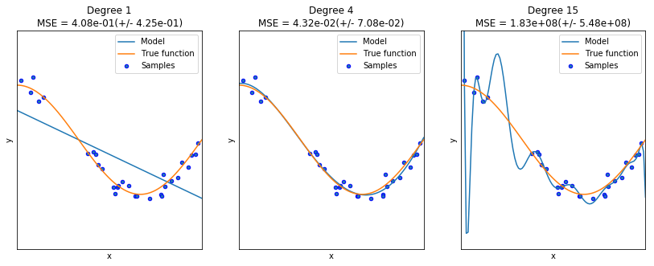

```python
import numpy as np
import matplotlib.pyplot as plt
from sklearn.pipeline import Pipeline
from sklearn.preprocessing import PolynomialFeatures
from sklearn.linear_model import LinearRegression
from sklearn.model_selection import cross_val_score
%matplotlib inline


def true_fun(X):
    return np.cos(1.5 * np.pi * X)

np.random.seed(0)

n_samples = 30
degrees = [1, 4, 15]

X = np.sort(np.random.rand(n_samples))
y = true_fun(X) + np.random.randn(n_samples) * 0.1

plt.figure(figsize=(14, 5))
for i in range(len(degrees)):
    ax = plt.subplot(1, len(degrees), i + 1)
    plt.setp(ax, xticks=(), yticks=())

    polynomial_features = PolynomialFeatures(degree=degrees[i],
                                             include_bias=False)
    linear_regression = LinearRegression()
    pipeline = Pipeline([("polynomial_features", polynomial_features),
                         ("linear_regression", linear_regression)])
    pipeline.fit(X[:, np.newaxis], y)

    # Evaluate the models using crossvalidation
    scores = cross_val_score(pipeline, X[:, np.newaxis], y,
                             scoring="neg_mean_squared_error", cv=10)

    X_test = np.linspace(0, 1, 100)
    plt.plot(X_test, pipeline.predict(X_test[:, np.newaxis]), label="Model")
    plt.plot(X_test, true_fun(X_test), label="True function")
    plt.scatter(X, y, edgecolor='b', s=20, label="Samples")
    plt.xlabel("x")
    plt.ylabel("y")
    plt.xlim((0, 1))
    plt.ylim((-2, 2))
    plt.legend(loc="best")
    plt.title("Degree {}\nMSE = {:.2e}(+/- {:.2e})".format(
        degrees[i], -scores.mean(), scores.std()))
```